# Lamb August weight - Heritability estimate and GWAS

Caelinn James

07 April 2021

**Written for R 4.0.2, last updated 01/07/21**

### Load packages

```r
library(RODBC)
library(data.table)
library(stringr)
library(splitstackshape)
library(qqman)
```

### Connect to the database

Note that from database front end version 2.22, it is important to click “Make R Friendly” in the queries section before running the analysis, or loading the pedigree will not work (will not work at all for prior front end versions)

```r
dv <- "C:/Users/s1944058/Documents/Sheep/Database/SoaySheep2.30.accdb"
con <- odbcConnectAccess2007(dv)
tbls <- sqlTables(con)
capturedata <- sqlFetch(con,"CaptureData")
sheep <- sqlFetch(con,"sys_SheepPlusBirthInfo")
```

Check to see if the files have loaded correctly (don’t worry about negative IDs or lots of NAs)…  
First the capture data file….

```r
head(capturedata)
```

```
##   CapRef CatchEventRef Trap   ID   Tag Retag CapYear CapMonth CapDay Time
## 1      2            NA <NA> 1540 NY195  <NA>    1985        8     15 <NA>
## 2      3            NA <NA> 1546 NY201  <NA>    1985        8     15 <NA>
## 3      4            NA <NA> 1055 OK001  <NA>    1985        8     12 <NA>
## 4      5            NA <NA>   94 SY143 OY001    1985        8     12 <NA>
## 5      6            NA <NA>  546 SB068 OB001    1985        8     12 <NA>
## 6      7            NA <NA> 1201 SG035 OG001    1985        8     12 <NA>
##   Measurer LiveMeasure Weight Foreleg Hindleg HornLen HornCirc Horn01 Horn02
## 1     <NA>           1    9.7      NA      NA      NA       NA     NA     NA
## 2     <NA>           1   12.5      NA      NA      NA       NA     NA     NA
## 3     <NA>           1   36.5      NA      NA      NA       NA     NA     NA
## 4     <NA>           1   38.4      NA      NA     615       NA     NA     NA
## 5     <NA>           1   25.0      NA      NA      NA       NA     NA     NA
## 6     <NA>           1   23.3      NA      NA     296       NA     NA     NA
##   Horn03 Horn04 Horn05 Horn06 Horn07 Horn08 Horn09 Horn10 LHbroken RHbroken
```

[output cut: 48 more lines]

Then the sheep file…

```r
head(sheep)
```

```
##      ID BirthRef MumSource Status Sex Coat Horn BirthYear BirthMonth BirthDay
## 1 -2644    11143         3  Dummy   2   NA   NA        NA         NA       NA
## 2 -2643       NA        NA  Dummy   2   NA   NA        NA         NA       NA
## 3 -2642    11142         3  Dummy   2   NA   NA        NA         NA       NA
## 4 -2641       NA        NA  Dummy   2   NA   NA        NA         NA       NA
## 5 -2640       NA        NA  Dummy   2   NA   NA        NA         NA       NA
## 6 -2639       NA        NA  Dummy   2   NA   NA        NA         NA       NA
##   MumID BirthWt CapAge BirthEasting BirthNorthing SibCount SibNoObserved TwinID
## 1  4106      NA     NA           NA            NA        0             0     NA
## 2    NA      NA     NA           NA            NA        0             0     NA
## 3 10114      NA     NA           NA            NA        0             0     NA
## 4    NA      NA     NA           NA            NA        0             0     NA
## 5    NA      NA     NA           NA            NA        0             0     NA
## 6    NA      NA     NA           NA            NA        0             0     NA
##   TripletID DeathYear DeathMonth DeathDay DeathType DeathEasting DeathNorthing
## 1        NA        NA         NA       NA        NA           NA            NA
## 2        NA        NA         NA       NA        NA           NA            NA
## 3        NA        NA         NA       NA        NA           NA            NA
## 4        NA        NA         NA       NA        NA           NA            NA
## 5        NA        NA         NA       NA        NA           NA            NA
## 6        NA        NA         NA       NA        NA           NA            NA
##   InCleitDeath
## 1           NA
## 2           NA
## 3           NA
## 4           NA
## 5           NA
## 6           NA
```

### Filter the data

Firstly, only include records of capture events that measured the weight.

```r
capturedataall <- merge(sheep,capturedata,by.x="ID")
capturedataall <- capturedataall[!is.na(capturedataall$Weight),]
```

We are only interested in the capture events that happened in August and to lambs

```r
capturedataall<- capturedataall[which(capturedataall$CapMonth == 8),]

capturedataall$Age <- capturedataall$CapYear - capturedataall$BirthYear
capturedataall$Age <- as.numeric(capturedataall$Age)
capturedataall <- capturedataall[!is.na(capturedataall$Age),]
capturedataall <- capturedataall[which(capturedataall$Age < 1),]
capturedataall <- capturedataall[!is.na(capturedataall$BirthWt),]

table(table(capturedataall$ID))
```

```
##
##    1    2
## 2424   42
```

In this model, we are allowing for repeated measures - in lambs there are only a handful of individuals who have been caught more than once, but we should still include their extra measures

```r
capturedataall$Sex[capturedataall$Sex == 3] <- 2
capturedataall <- capturedataall[!is.na(capturedataall$Sex),]
capturedataall$Sex <- as.factor(capturedataall$Sex)
capturedataall$SibCount <- as.factor(capturedataall$SibCount)

Villdens <- sqlFetch(con,"HirtaVillPop")
capturedataall <- merge(capturedataall,Villdens[,c("VillTotal","Year")],by.x="CapYear",by.y="Year",all.x=T)
capturedataall <- capturedataall[!is.na(capturedataall$VillTotal),]
```

```r
SNPs_50K <- read.table("~/Documents/Sheep/50KSNP/Plates_1to87_QC3.fam")
capturedataall <- capturedataall[which(capturedataall$ID %in% SNPs_50K$V2),]
SNPs_HD <- read.table("~/Documents/Sheep/HDSNP/sheep_geno_imputed_oar31_17052020.fam")
capturedataall <- capturedataall[which(capturedataall$ID %in% SNPs_HD$V2),]
```

Calculate the age of the sheep in days of how old they are

```r
capturedataall <- capturedataall[!is.na(capturedataall$BirthMonth),]
capturedataall <- capturedataall[!is.na(capturedataall$BirthDay),]
capturedataall$BirthDate <- paste0(capturedataall$BirthYear,"/",capturedataall$BirthMonth,"/",capturedataall$BirthDay)

capturedataall$Date <- as.numeric(format(as.Date(capturedataall$BirthDate),"%j"))
capturedataall$CapDate <- paste0(capturedataall$CapYear,"/",capturedataall$CapMonth,"/",capturedataall$CapDay)
capturedataall$AgeDate <- as.numeric(format(as.Date(capturedataall$CapDate),"%j"))

capturedataall$AugCapAge <- capturedataall$AgeDate - capturedataall$Date
```

This leaves us with **2276** records from **2235** individuals, and the following distribution of weight:

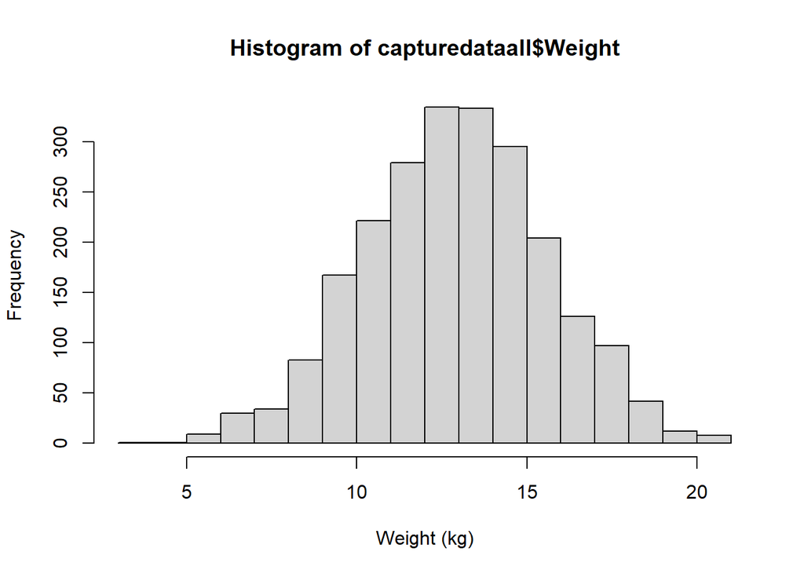

```r
hist(capturedataall$Weight,xlab="Weight (kg)")
```

We will now save a list of phenotypes, fixed effects and random effects. First:

```r
LambweightPhenotypes <- cbind(rep(1,nrow(capturedataall)),as.numeric(as.character(capturedataall$CapRef)),as.character(capturedataall$ID),as.character(capturedataall$Weight))

LambweightAssoc <- cbind(rep(1,nrow(capturedataall)),as.character(capturedataall$CapRef),capturedataall$Sex,capturedataall$SibCount)

LambweightQAssoc <-cbind(rep(1,nrow(capturedataall)),as.character(capturedataall$CapRef),capturedataall$VillTotal,capturedataall$AugCapAge)

LambweightRandom <-cbind(rep(1,nrow(capturedataall)),as.character(capturedataall$CapRef),capturedataall$CapYear,capturedataall$MumID,capturedataall$ID)
colnames(LambweightRandom) <- c("FID","IID","BirthYear","MumID","ID")


write.table(LambweightPhenotypes,file="~/Documents/Sheep/R/AugustWeight/LambWeightPhenotypes.txt",row.names = F,col.names = F,quote = F)

write.table(LambweightAssoc,file="~/Documents/Sheep/R/AugustWeight/LambWeightAssoc.txt",row.names = F,col.names = F,quote = F)

write.table(LambweightQAssoc,file="~/Documents/Sheep/R/AugustWeight/LambWeightQAssoc.txt",row.names = F,col.names = F,quote = F)

write.table(LambweightRandom,file="~/Documents/Sheep/R/AugustWeight/LambWeightRandom.txt",row.names = F,col.names = T,quote = F)
```

## Prep the genotype files

> #!/bin/sh  
> #$ -cwd  
> #$ -l h_rt=0:30:00  
> #$ -pe sharedmem 1  
> #$ -l h_vmem=50G

> sort -k 3,3 LambWeightPhenotypes.txt > Pheno150K.txt  
> awk ‘($2 >0)’ ../InputData/Plates_1to87_QC3.ped > Ped150K.ped  
> sort -k 2,2 Ped150K.ped > Ped250K.ped  
> join -1 3 -2 2 Pheno150K.txt Ped250K.ped > Ped350K.ped  
> cut -d ’ ’ -f 1,4,5 –complement Ped350K.ped > LambWeight50K.ped

> sort -k 3,3 LambWeightPhenotypes.txt > Pheno1HD.txt  
> awk ‘($2 >0)’ ../InputData/sheep_geno_imputed_oar31_17052020.ped > Ped1HD.ped  
> sort -k 2,2 Ped1HD.ped > Ped2HD.ped  
> join -1 3 -2 2 Pheno1HD.txt Ped2HD.ped > Ped3HD.ped  
> cut -d ’ ’ -f 1,4,5 –complement Ped3HD.ped > LambWeightHD.ped

## Heritability Estimates

### 50K

> #!/bin/sh  
> #$ -cwd  
> #$ -l h_rt=1:00:00  
> #$ -pe sharedmem 1  
> #$ -l h_vmem=100G  
> #$ -M s1944058@sms.ed.ac.uk  
> #$ -m baes  
> . /etc/profile.d/modules.sh

> module load igmm/apps/dissect/1.15.2c  
> module load igmm/apps/plink/1.90b4

> plink –file ../InputData/Plates_1to87_QC3 --ped LambWeight50K.ped --sheep --not-chr 0,X --make-bed --out 50K/LambWeight50K

> mpirun -np 8 dissect.mpich --reml --bfile 50K/LambWeight50K --pheno LambWeightPhenotypes.txt --pheno-col 2 --blue --covar LambWeightAssoc.txt --qcovar LambWeightQAssoc.txt --random-effects LambWeightRandom.txt --random-effects-cols 1 2 3 --out 50K/LambWeight_50K_H2

> if [[ -f 50K/LambWeight_50K_H2.badsnps ]]  
> then  
> plink --bfile ../InputData/Plates_1to87_QC3 --sheep --exclude 50K/LambWeight_50K_H2.badsnps --make-bed --out 50K/LambWeight_50K_H2

> mpirun -np 8 dissect.mpich --reml --bfile 50K/LambWeight_50K_H2 --pheno LambWeightPhenotypes.txt --pheno-col 2 --blue --covar LambWeightAssoc.txt --qcovar LambWeightQAssoc.txt --random-effects LambWeightRandom.txt --random-effects-cols 1 2 3 --out 50K/LambWeight_50K_H2  
> fi

> mpirun -np 8 dissect.mpich --reml --bfile 50K/LambWeight50K --pheno LambWeightPhenotypes.txt --pheno-col 2 --blue --random-effects LambWeightRandom.txt --random-effects-cols 1 2 3 --out 50K/LambWeight_50K_TotalPhenotypeVariance

> if [[ -f 50K/LambWeight_50K_TotalPhenotypeVariance.badsnps ]]  
> then  
> plink --bfile ../InputData/Plates_1to87_QC3 --sheep --exclude 50K/LambWeight_50K_TotalPhenotypeVariance.badsnps --make-bed --out 50K/LambWeight_50K_TotalPhenotypeVariance

> mpirun -np 8 dissect.mpich --reml --bfile 50K/LambWeight_50K_TotalPhenotypeVariance --pheno LambWeightPhenotypes.txt --pheno-col 2 --blue --random-effects LambWeightRandom.txt --random-effects-cols 1 2 3 --out 50K/LambWeight_50K_TotalPhenotypeVariance  
> fi

```r
FixedEffects_50K
```

```
##         NAME        BETA        STD
## 1        Sex -1.58542000 0.08535990
## 2      Twins -2.55625000 0.11528700
## 3   Triplets  0.39904000 1.96804000
## 4 Population -0.00505798 0.00152602
## 5 Age (days)  0.07301770 0.00623179
```

```r
RandomEffects_50K
```

```
##                            NAME      BETA       STD
## 1:                  Var(GRM_p1)  0.493886  0.132758
## 2:            Var(BirthYear_p1)  0.908577  0.263175
## 3:                Var(MumID_p1)  0.831087   0.13479
## 4:                   Var(ID_p1)   3.12589  0.148327
## 5:                    Var(E_p1) 0.0724898 0.0160278
## 6: Var(GRM_p1)/Var(Phenotype_1) 0.0909227 0.0243163
```

### HD

> #!/bin/sh  
> #$ -cwd  
> #$ -l h_rt=1:00:00  
> #$ -pe sharedmem 1  
> #$ -l h_vmem=100G  
> #$ -M s1944058@sms.ed.ac.uk  
> #$ -m baes  
> . /etc/profile.d/modules.sh

> module load igmm/apps/dissect/1.15.2c  
> module load igmm/apps/plink/1.90b4

> plink –file ../InputData/sheep_geno_imputed_oar31_17052020 --ped LambWeightHD.ped --sheep --not-chr 0,X --make-bed --out HD/LambWeightHD

> mpirun -np 8 dissect.mpich --reml --bfile HD/LambWeightHD --pheno LambWeightPhenotypes.txt --pheno-col 2 --blue --covar LambWeightAssoc.txt --qcovar LambWeightQAssoc.txt --random-effects LambWeightRandom.txt --random-effects-cols 1 2 3 --out HD/LambWeight_HD_H2

> if [[ -f HD/LambWeight_HD_H2.badsnps ]]  
> then  
> plink --bfile ../InputData/Plates_1to87_QC3 --sheep --exclude HD/LambWeight_HD_H2.badsnps --make-bed --out HD/LambWeight_HD_H2

> mpirun -np 8 dissect.mpich --reml --bfile HD/LambWeight_HD_H2 --pheno LambWeightPhenotypes.txt --pheno-col 2 --blue --covar LambWeightAssoc.txt --qcovar LambWeightQAssoc.txt --random-effects LambWeightRandom.txt --random-effects-cols 1 2 3 --out HD/LambWeight_HD_H2  
> fi

> mpirun -np 8 dissect.mpich --reml --bfile HD/LambWeightHD --pheno LambWeightPhenotypes.txt --pheno-col 2 --blue --random-effects LambWeightRandom.txt --random-effects-cols 1 2 3 --out HD/LambWeight_HD_TotalPhenotypeVariance

> if [[ -f HD/LambWeight_HD_TotalPhenotypeVariance.badsnps ]]  
> then  
> plink --bfile ../InputData/Plates_1to87_QC3 --sheep --exclude HD/LambWeight_HD_TotalPhenotypeVariance.badsnps --make-bed --out HD/LambWeight_HD_TotalPhenotypeVariance

> mpirun -np 8 dissect.mpich --reml --bfile HD/LambWeight_HD_TotalPhenotypeVariance --pheno LambWeightPhenotypes.txt --pheno-col 2 --blue --random-effects LambWeightRandom.txt --random-effects-cols 1 2 3 --out HD/LambWeight_HD_TotalPhenotypeVariance  
> fi

```r
FixedEffects_HD
```

```
##         NAME        BETA        STD
## 1        Sex -1.58667000 0.08544650
## 2      Twins -2.55307000 0.11538200
## 3   Triplets  0.41694300 1.97043000
## 4 Population -0.00507157 0.00152433
## 5 Age (days)  0.07290450 0.00623429
```

```r
RandomEffects_HD
```

```
##                            NAME      BETA       STD
## 1:                  Var(GRM_p1)  0.476067  0.131986
## 2:            Var(BirthYear_p1)  0.906156   0.26249
## 3:                Var(MumID_p1)  0.829832  0.135091
## 4:                   Var(ID_p1)   3.14013   0.14887
## 5:                    Var(E_p1) 0.0725101 0.0160329
## 6: Var(GRM_p1)/Var(Phenotype_1) 0.0877592 0.0242371
```

### GWAS

> #!/bin/sh  
> #$ -cwd  
> #$ -l h_rt=2:00:00  
> #$ -pe sharedmem 1  
> #$ -l h_vmem=200G  
> #$ -t 1-26  
> #$ -tc 5  
> #$ -M s1944058@sms.ed.ac.uk  
> #$ -m baes  
> . /etc/profile.d/modules.sh

> module load igmm/apps/dissect/1.15.2c  
> module load igmm/apps/plink/1.90b4

> i=$_TASK_ID

> plink --bfile ../InputData/Plates_1to87_QC3 --ped LambWeight50K.ped --sheep --not-chr ${i},X --keep LambWeightPhenotypes.txt --make-bed --out 50K/NoChr${i}

> mpirun -np 8 dissect.mpich --make-grm --bfile 50K/NoChr${i} --out 50K/NoChr${i}_GRM

> echo "50K/Chr${i} 50K/NoChr${i}_GRM" > 50K/GWAS_GRM${i}.txt

> plink --bfile ../InputData/Plates_1to87_QC3 --ped LambWeight50K.ped --sheep --chr ${i} --keep LambWeightPhenotypes.txt --make-bed --out 50K/Chr${i}

> if [[ -f 50K/NoChr${i}_GRM.badsnps ]]  
> then  
> plink --bfile 50K/NoChr${i} --sheep --exclude 50K/NoChr${i}_GRM.badsnps --make-bed --out 50K/NoChr${i}_2

> mpirun -np 8 dissect.mpich --make-grm --bfile 50K/NoChr${i}_2 --out 50K/NoChr${i}_GRM

> fi

> mpirun -np 8 dissect.mpich --gwas --bfile-grm-list 50K/GWAS_GRM${i}.txt --pheno LambWeightPhenotypes.txt --pheno-col 2 --covar LambWeightAssoc.txt --qcovar LambWeightQAssoc.txt --random-effects LambWeightRandom.txt --random-effects-cols 1 2 3 --out 50K/LambWeight_50K_GWAS_Chr${i}

> if [[ -f 50K/LambWeight_50K_GWAS_Chr${i}.badsnps ]]  
> then  
> plink --bfile 50K/Chr${i} --sheep --exclude 50K/LambWeight_50K_GWAS_Chr${i}.badsnps --make-bed --out 50K/Chr${i}_2

> echo "50K/Chr${i}_2 50K/NoChr${i}_GRM" > 50K/GWAS_GRM${i}.txt

> mpirun -np 8 dissect.mpich --gwas --bfile-grm-list 50K/GWAS_GRM${i}.txt --pheno LambWeightPhenotypes.txt --pheno-col 2 --covar LambWeightAssoc.txt --qcovar LambWeightQAssoc.txt --random-effects LambWeightRandom.txt --random-effects-cols 1 2 3 --out 50K/LambWeight_50K_GWAS_Chr${i}  
> fi

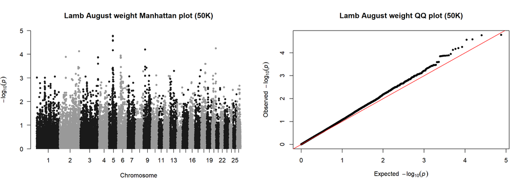

```r
files = list.files(pattern="LambWeight_50K_GWAS_Chr",recursive=TRUE)

SNPresults = do.call(rbind, lapply(files, function(x) read.table(x,header=T)))

bimFile <- read.table("C:/Users/s1944058/Documents/Sheep/50KSNP/Plates_1to87_QC3.bim",header=F)

GWAS50KResults <- merge(bimFile,SNPresults[,c("SNP","PV"),],by.x="V2",by.y="SNP",all.x=FALSE,all.y=TRUE)
colnames(GWAS50KResults) <- c("SNP","Chr","V3","Pos","Ref","Minor","PV")
GWAS50KResults$Chr <- as.numeric(GWAS50KResults$Chr)
par(mfrow=c(1,2))
manhattan(GWAS50KResults,chr="Chr",bp="Pos",p="PV",snp="SNP", main = "Lamb August weight Manhattan plot (50K)", genomewideline = -log10(0.05/20082),suggestiveline = FALSE)
qq(GWAS50KResults$PV,main="Lamb August weight QQ plot (50K)")
```

```r
SNPs <- GWAS50KResults[which(GWAS50KResults$PV < (0.05/20082) ),c("Chr","Pos","SNP","PV")]
SNPs[order(SNPs$PV),]
```

```
## [1] Chr Pos SNP PV
## <0 rows> (or 0-length row.names)
```

### Imputed SNP data

> #!/bin/sh  
> #$ -cwd  
> #$ -l h_rt=3:00:00  
> #$ -pe sharedmem 1  
> #$ -l h_vmem=200G  
> #$ -t 1-26  
> #$ -tc 5  
> #$ -M s1944058@sms.ed.ac.uk  
> #$ -m baes  
> . /etc/profile.d/modules.sh

> module load igmm/apps/dissect/1.15.2c  
> module load igmm/apps/plink/1.90b4

> i=$_TASK_ID

> plink --bfile ../InputData/sheep_geno_imputed_oar31_17052020 --ped LambWeightHD.ped --sheep --not-chr ${i},X --keep LambWeightPhenotypes.txt --make-bed --out HD/NoChr${i}

> mpirun -np 8 dissect.mpich --make-grm --bfile HD/NoChr${i} --out HD/NoChr${i}_GRM

> echo "HD/Chr${i} HD/NoChr${i}_GRM" > HD/GWAS_GRM${i}.txt

> plink --bfile ../InputData/sheep_geno_imputed_oar31_17052020 --ped LambWeightHD.ped --sheep --chr ${i} --keep LambWeightPhenotypes.txt --make-bed --out HD/Chr${i}

> if [[ -f HD/NoChr${i}_GRM.badsnps ]]  
> then  
> plink --bfile HD/NoChr${i} --sheep --exclude HD/NoChr${i}_GRM.badsnps --make-bed --out HD/NoChr${i}_2

> mpirun -np 8 dissect.mpich --make-grm --bfile HD/NoChr${i}_2 --out HD/NoChr${i}_GRM

> fi

> mpirun -np 8 dissect.mpich --gwas --bfile-grm-list HD/GWAS_GRM${i}.txt --pheno LambWeightPhenotypes.txt --pheno-col 2 --covar LambWeightAssoc.txt --qcovar LambWeightQAssoc.txt --random-effects LambWeightRandom.txt --random-effects-cols 1 2 3 --out HD/LambWeight_HD_GWAS_Chr${i}

> if [[ -f HD/LambWeight_HD_GWAS_Chr${i}.badsnps ]]  
> then  
> plink --bfile HD/Chr${i} --sheep --exclude HD/LambWeight_HD_GWAS_Chr${i}.badsnps --make-bed --out HD/Chr${i}_2

> echo "HD/Chr${i}_2 HD/NoChr${i}_GRM" > HD/GWAS_GRM${i}.txt

> mpirun -np 8 dissect.mpich --gwas --bfile-grm-list HD/GWAS_GRM${i}.txt --pheno LambWeightPhenotypes.txt --pheno-col 2 --covar LambWeightAssoc.txt --qcovar LambWeightQAssoc.txt --random-effects LambWeightRandom.txt --random-effects-cols 1 2 3 --out HD/LambWeight_HD_GWAS_Chr${i}  
> fi

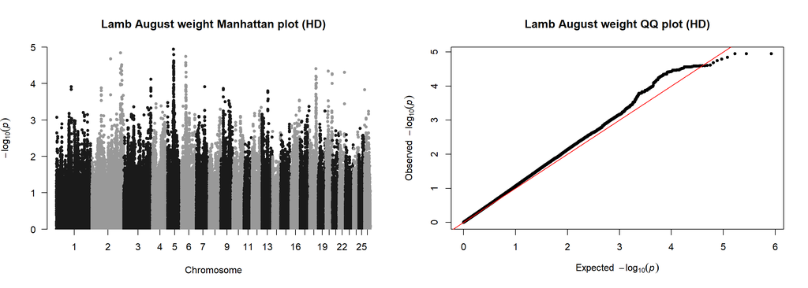

```r
files = list.files(pattern="LambWeight_HD_GWAS_Chr",recursive=TRUE)

SNPresults = do.call(rbind, lapply(files, function(x) read.table(x,header=T)))

bimFile <- read.table("C:/Users/s1944058/Documents/Sheep/HDSNP/sheep_geno_imputed_oar31_17052020.bim",header=F)

GWASHDResults <- merge(bimFile,SNPresults[,c("SNP","PV"),],by.x="V2",by.y="SNP",all.x=FALSE,all.y=TRUE)
colnames(GWASHDResults) <- c("SNP","Chr","V3","Pos","Ref","Minor","PV")
GWASHDResults$Chr <- as.numeric(GWASHDResults$Chr)
par(mfrow=c(1,2))
manhattan(GWASHDResults,chr="Chr",bp="Pos",p="PV",snp="SNP", main = "Lamb August weight Manhattan plot (HD)", genomewideline = -log10(0.05/39149),suggestiveline = FALSE)
qq(GWASHDResults$PV,main="Lamb August weight QQ plot (HD)")
```

```r
SNPs <- GWASHDResults[which(GWASHDResults$PV < (0.05/39149) ),c("Chr","Pos","SNP","PV")]
SNPs[order(SNPs$PV),]
```

```
## [1] Chr Pos SNP PV
## <0 rows> (or 0-length row.names)
```

## **FINAL RESULTS**

### 50K

```r
RandomEffects_50K[nrow(RandomEffects_50K),]
```

```
##                            NAME      BETA       STD
## 1: Var(GRM_p1)/Var(Phenotype_1) 0.0909227 0.0243163
```

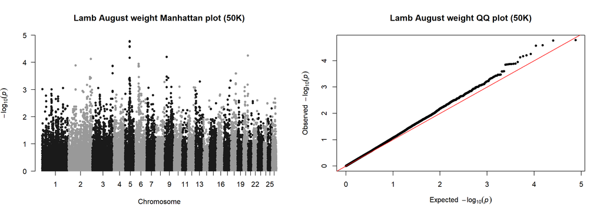

```r
par(mfrow=c(1,2))
manhattan(GWAS50KResults,chr="Chr",bp="Pos",p="PV",snp="SNP", main = "Lamb August weight Manhattan plot (50K)", genomewideline = -log10(0.05/20082),suggestiveline = FALSE)
qq(GWAS50KResults$PV,main="Lamb August weight QQ plot (50K)")
```

### HD

```r
RandomEffects_HD[nrow(RandomEffects_HD),]
```

```
##                            NAME      BETA       STD
## 1: Var(GRM_p1)/Var(Phenotype_1) 0.0877592 0.0242371
```

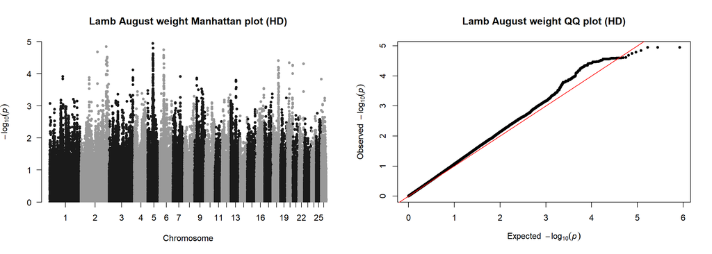

```r
par(mfrow=c(1,2))
manhattan(GWASHDResults,chr="Chr",bp="Pos",p="PV",snp="SNP", main = "Lamb August weight Manhattan plot (HD)", genomewideline = -log10(0.05/39149),suggestiveline = FALSE)
qq(GWASHDResults$PV,main="Lamb August weight QQ plot (HD)")
```